# T#002_Practice_Case_Study_Bellabeat

Laks_Malhotra

2022-06-26

This is a Case study, all the required pre-requisition data are provided by the Google’s Data analytics professional certificate’s 8th module. This capstone project shall contain all the necessary code and literature associated with this project. We will follow Google’s ASK, PREPARE, PROCESS, ANALYZE, SHARE & ACT Template for the Project to keep the process streamline.

## ASK

This is the first step in the data analytics project in which we will identify and establish the Business task and complete the project based on that. Following questions might help in pinpointing the primary objective of the project.

*What is the problem you are trying to solve?* Our organization’s objective is to understand the customer behavior in the market who already use the smart devices, They also want more insights on statistics associated with Fit bit Fitness user data.

*Why should stakeholder invest in Solution?* Because, they might have a potential of becoming a big player in global smart devices market for women, using the insights from this project to develop targeted marketing strategy to improve their customer base.

*How will we achieve the solution?*

The process is divided into following 3 steps:

*What are some patterns/trends in user’s behavior of smart devices?*

*How can Bellabeat use the insights from the analysis and apply them to Bellabeat customers?*

*How will the recommendations from the insights be used for a potential future marketing strategy?*

I am tasked with the first question, so this project only focus on that for now.

*How will insight drive the business decision?*

Insights generated will be based on the patterns or trends generated by the Fitbit Fitness User data, which will guide in developing a better targeted marketing strategy for Bellabeat customers.

**Business Task**

We are going to identify the statistics and summary of customer’s behavior for Fitbit Fitness User Data; and apply the insights to give recommendations to improve one of the Bellabeat products in a presentation to the management.

Then we will use this information to develop a marketing campaign to target Bellabeat current and potential customers. Our job as a Junior Analyst is to clean, process, analyze and visualize the given data in pursuit of identifying patterns in different records of smart device users.

**Key Stakeholders**

**Urska Srsen:**—————Founder & CCO.

**Sandro Mur:**—————Co-founder & member of board of Directors

**Bellabeat Marketing Analytics Team:**——Team of Data Analysts responsible for collecting, analyzing and reporting the insights from the data to guide the organization’s marketing efforts.

## PREPARE

### Background & Data Structure

**Data Sets** : Fitbit Fitness Trackers Data

**Data Source** : Data is made available by Mobius at kaggle.com. at [this Link](https://www.kaggle.com/datasets/arashnic/fitbit).

**About Data** : This open source data contains records for fitness trackes that collects data on daily user’s physical activities.

**Data Format** : Wide, csv format.

**Number of Files** : 12

**file Name** : “dailyActiviy_merged.csv”, “Sleepday_merged.csv”, “dailyCalories_merged.csv”, “Heartrate_Seconds_merged.csv”, “dailyIntensites_merged.csv”, WeightLoginfo.csv”.

*ROCCC verification for Data*

**Reliable**: Data Source Mobius has made this data available in CCO: public domain.

**Original**: [Here’s]((https://www.kaggle.com/datasets/arashnic/fitbit). the link to the data source and this is a [link](https://bellabeat.com/) to the original company website.

**Comprehensive**: Observing the data sets in Microsoft excel spreadsheet indicated that it contains required and relevant information to conduct the analysis.

**Current**: Data used for analysis is given by the customers voluntarily for one month from 12th of april to 12th of may during the year of 2016.

**Cited**: CCO: Public Domain.

We have established the credibility of our data let’s move on to the processing stage

## PROCESS

In this stage we will clean the data in our working environment and prepare it for the analysis.

*Setting up the working environment*

For this project we are going to use R Studio with R programming language.

Let’s load the required libraries:

```r
library(tidyverse)
library(lubridate)
library(janitor)
library(skimr)
```

Let’s upload the data sets to the working environment within the specific data frames:

```r
dailyactivity <- read.csv("C:/Users/laksd/OneDrive/Desktop/Analytics/Datasets/fitbit_Data_for_Bellabeat/Fitabase Data 4.12.16-5.12.16/dailyActivity_merged.csv")

sleepday <- read.csv("C:/Users/laksd/OneDrive/Desktop/Analytics/Datasets/fitbit_Data_for_Bellabeat/Fitabase Data 4.12.16-5.12.16/sleepDay_merged.csv")

dailycalories <- read.csv("C:/Users/laksd/OneDrive/Desktop/Analytics/Datasets/fitbit_Data_for_Bellabeat/Fitabase Data 4.12.16-5.12.16/dailyCalories_merged.csv")

dailyintensity <- read.csv("C:/Users/laksd/OneDrive/Desktop/Analytics/Datasets/fitbit_Data_for_Bellabeat/Fitabase Data 4.12.16-5.12.16/dailyIntensities_merged.csv")

weightlog <- read.csv("C:/Users/laksd/OneDrive/Desktop/Analytics/Datasets/fitbit_Data_for_Bellabeat/Fitabase Data 4.12.16-5.12.16/weightLogInfo_merged.csv")
```

Now, that we have uploaded our data , let’s view the data in the environment

**Data wrangling and Cleaning**

```r
#Let's see how our data looks like:
str(dailyactivity)
```

```
## 'data.frame':    940 obs. of  15 variables:
##  $ Id                      : num  1.5e+09 1.5e+09 1.5e+09 1.5e+09 1.5e+09 ...
##  $ ActivityDate            : chr  "4/12/2016" "4/13/2016" "4/14/2016" "4/15/2016" ...
##  $ TotalSteps              : int  13162 10735 10460 9762 12669 9705 13019 15506 10544 9819 ...
##  $ TotalDistance           : num  8.5 6.97 6.74 6.28 8.16 ...
##  $ TrackerDistance         : num  8.5 6.97 6.74 6.28 8.16 ...
##  $ LoggedActivitiesDistance: num  0 0 0 0 0 0 0 0 0 0 ...
##  $ VeryActiveDistance      : num  1.88 1.57 2.44 2.14 2.71 ...
##  $ ModeratelyActiveDistance: num  0.55 0.69 0.4 1.26 0.41 ...
##  $ LightActiveDistance     : num  6.06 4.71 3.91 2.83 5.04 ...
##  $ SedentaryActiveDistance : num  0 0 0 0 0 0 0 0 0 0 ...
##  $ VeryActiveMinutes       : int  25 21 30 29 36 38 42 50 28 19 ...
##  $ FairlyActiveMinutes     : int  13 19 11 34 10 20 16 31 12 8 ...
##  $ LightlyActiveMinutes    : int  328 217 181 209 221 164 233 264 205 211 ...
##  $ SedentaryMinutes        : int  728 776 1218 726 773 539 1149 775 818 838 ...
##  $ Calories                : int  1985 1797 1776 1745 1863 1728 1921 2035 1786 1775 ...
```

```r
str(dailycalories)
```

```
## 'data.frame':    940 obs. of  3 variables:
##  $ Id         : num  1.5e+09 1.5e+09 1.5e+09 1.5e+09 1.5e+09 ...
##  $ ActivityDay: chr  "4/12/2016" "4/13/2016" "4/14/2016" "4/15/2016" ...
##  $ Calories   : int  1985 1797 1776 1745 1863 1728 1921 2035 1786 1775 ...
```

```r
str(dailyintensity)
```

```
## 'data.frame':    940 obs. of  10 variables:
##  $ Id                      : num  1.5e+09 1.5e+09 1.5e+09 1.5e+09 1.5e+09 ...
##  $ ActivityDay             : chr  "4/12/2016" "4/13/2016" "4/14/2016" "4/15/2016" ...
##  $ SedentaryMinutes        : int  728 776 1218 726 773 539 1149 775 818 838 ...
##  $ LightlyActiveMinutes    : int  328 217 181 209 221 164 233 264 205 211 ...
##  $ FairlyActiveMinutes     : int  13 19 11 34 10 20 16 31 12 8 ...
##  $ VeryActiveMinutes       : int  25 21 30 29 36 38 42 50 28 19 ...
##  $ SedentaryActiveDistance : num  0 0 0 0 0 0 0 0 0 0 ...
##  $ LightActiveDistance     : num  6.06 4.71 3.91 2.83 5.04 ...
##  $ ModeratelyActiveDistance: num  0.55 0.69 0.4 1.26 0.41 ...
##  $ VeryActiveDistance      : num  1.88 1.57 2.44 2.14 2.71 ...
```

```r
str(sleepday)
```

```
## 'data.frame':    413 obs. of  5 variables:
##  $ Id                : num  1.5e+09 1.5e+09 1.5e+09 1.5e+09 1.5e+09 ...
##  $ SleepDay          : chr  "4/12/2016 12:00:00 AM" "4/13/2016 12:00:00 AM" "4/15/2016 12:00:00 AM" "4/16/2016 12:00:00 AM" ...
##  $ TotalSleepRecords : int  1 2 1 2 1 1 1 1 1 1 ...
##  $ TotalMinutesAsleep: int  327 384 412 340 700 304 360 325 361 430 ...
##  $ TotalTimeInBed    : int  346 407 442 367 712 320 377 364 384 449 ...
```

```r
str(weightlog)
```

```
## 'data.frame':    67 obs. of  8 variables:
##  $ Id            : num  1.50e+09 1.50e+09 1.93e+09 2.87e+09 2.87e+09 ...
##  $ Date          : chr  "5/2/2016 11:59:59 PM" "5/3/2016 11:59:59 PM" "4/13/2016 1:08:52 AM" "4/21/2016 11:59:59 PM" ...
##  $ WeightKg      : num  52.6 52.6 133.5 56.7 57.3 ...
##  $ WeightPounds  : num  116 116 294 125 126 ...
##  $ Fat           : int  22 NA NA NA NA 25 NA NA NA NA ...
##  $ BMI           : num  22.6 22.6 47.5 21.5 21.7 ...
##  $ IsManualReport: chr  "True" "True" "False" "True" ...
##  $ LogId         : num  1.46e+12 1.46e+12 1.46e+12 1.46e+12 1.46e+12 ...
```

```r
#Now, let's see the columns attributes :
colnames(dailyactivity)
```

```
##  [1] "Id"                       "ActivityDate"
##  [3] "TotalSteps"               "TotalDistance"
##  [5] "TrackerDistance"          "LoggedActivitiesDistance"
##  [7] "VeryActiveDistance"       "ModeratelyActiveDistance"
##  [9] "LightActiveDistance"      "SedentaryActiveDistance"
## [11] "VeryActiveMinutes"        "FairlyActiveMinutes"
## [13] "LightlyActiveMinutes"     "SedentaryMinutes"
## [15] "Calories"
```

```r
colnames(dailycalories)
```

```
## [1] "Id"          "ActivityDay" "Calories"
```

```r
colnames(dailyintensity)
```

```
##  [1] "Id"                       "ActivityDay"
##  [3] "SedentaryMinutes"         "LightlyActiveMinutes"
##  [5] "FairlyActiveMinutes"      "VeryActiveMinutes"
##  [7] "SedentaryActiveDistance"  "LightActiveDistance"
##  [9] "ModeratelyActiveDistance" "VeryActiveDistance"
```

```r
colnames(sleepday)
```

```
## [1] "Id"                 "SleepDay"           "TotalSleepRecords"
## [4] "TotalMinutesAsleep" "TotalTimeInBed"
```

```r
colnames(weightlog)
```

```
## [1] "Id"             "Date"           "WeightKg"       "WeightPounds"
## [5] "Fat"            "BMI"            "IsManualReport" "LogId"
```

From the previous str function we found out the “date” columns in all the datasets are in “character” format , but it should be in the correct “Datetime” format. Every other column attributes seem to be in the respective data type.

Now, let’s standaradize the format for the dataframes in the given code chunk:

```r
dailyactivity$ActivityDate <- as.Date(dailyactivity$ActivityDate, format = "%m/%d/%y")

dailyintensity$ActivityDay <- as.Date(dailyintensity$ActivityDay, format = "%m/%d/%y")

sleepday$SleepDay <- as.Date(sleepday$SleepDay, format = "%m/%d/%y")

dailycalories$ActivityDay <- as.Date(dailycalories$ActivityDay, format = "%m/%d/%y")

weightlog$Date <- as.Date(weightlog$Date, format = "%m/%d/%y")
```

Now, let’s use function class for the data frames to check for the consistency in the “date” columns

```r
class(dailyactivity$ActivityDate)
```

```
## [1] "Date"
```

```r
class(dailycalories$ActivityDay)
```

```
## [1] "Date"
```

```r
class(dailyintensity$ActivityDay)
```

```
## [1] "Date"
```

```r
class(sleepday$SleepDay)
```

```
## [1] "Date"
```

```r
class(weightlog$Date)
```

```
## [1] "Date"
```

If our result shows a consistent data type for the columns, then we move on to the next step.

Let’s now check for missing values:

```r
sum(is.na(dailyactivity))
```

```
## [1] 0
```

```r
sum(is.na(sleepday))
```

```
## [1] 0
```

```r
sum(is.na(dailycalories))
```

```
## [1] 0
```

```r
sum(is.na(dailyintensity))
```

```
## [1] 0
```

```r
sum(is.na(weightlog))
```

```
## [1] 65
```

We observe “weight log” data frame have 65 missing values.

```r
sleepday <- sleepday %>%
  rename(Date = SleepDay)

dailyactivity <- dailyactivity %>%
  rename(Date = ActivityDate)

dailyintensity <- dailyintensity %>%
  rename(Date = ActivityDay)

ActiveSleep <- merge(sleepday, dailyactivity, by = c("Id", "Date"))

IntensityWeight <- merge(dailyintensity, weightlog, by = c("Id", "Date"))
```

Now, we have two major data frames which contains all the columns and records that we need for our analysis:

```r
#Let's Check them out for double checking the requirements:
glimpse(ActiveSleep)
```

```
## Rows: 413
## Columns: 18
## $ Id                       <dbl> 1503960366, 1503960366, 1503960366, 150396036…
## $ Date                     <date> 2020-04-12, 2020-04-13, 2020-04-15, 2020-04-…
## $ TotalSleepRecords        <int> 1, 2, 1, 2, 1, 1, 1, 1, 1, 1, 1, 1, 1, 1, 1, …
## $ TotalMinutesAsleep       <int> 327, 384, 412, 340, 700, 304, 360, 325, 361, …
## $ TotalTimeInBed           <int> 346, 407, 442, 367, 712, 320, 377, 364, 384, …
## $ TotalSteps               <int> 13162, 10735, 9762, 12669, 9705, 15506, 10544…
## $ TotalDistance            <dbl> 8.50, 6.97, 6.28, 8.16, 6.48, 9.88, 6.68, 6.3…
## $ TrackerDistance          <dbl> 8.50, 6.97, 6.28, 8.16, 6.48, 9.88, 6.68, 6.3…
## $ LoggedActivitiesDistance <dbl> 0, 0, 0, 0, 0, 0, 0, 0, 0, 0, 0, 0, 0, 0, 0, …
## $ VeryActiveDistance       <dbl> 1.88, 1.57, 2.14, 2.71, 3.19, 3.53, 1.96, 1.3…
## $ ModeratelyActiveDistance <dbl> 0.55, 0.69, 1.26, 0.41, 0.78, 1.32, 0.48, 0.3…
## $ LightActiveDistance      <dbl> 6.06, 4.71, 2.83, 5.04, 2.51, 5.03, 4.24, 4.6…
## $ SedentaryActiveDistance  <dbl> 0, 0, 0, 0, 0, 0, 0, 0, 0, 0, 0, 0, 0, 0, 0, …
## $ VeryActiveMinutes        <int> 25, 21, 29, 36, 38, 50, 28, 19, 41, 39, 73, 3…
## $ FairlyActiveMinutes      <int> 13, 19, 34, 10, 20, 31, 12, 8, 21, 5, 14, 23,…
## $ LightlyActiveMinutes     <int> 328, 217, 209, 221, 164, 264, 205, 211, 262, …
## $ SedentaryMinutes         <int> 728, 776, 726, 773, 539, 775, 818, 838, 732, …
## $ Calories                 <int> 1985, 1797, 1745, 1863, 1728, 2035, 1786, 177…
```

```r
glimpse(IntensityWeight)
```

```
## Rows: 67
## Columns: 16
## $ Id                       <dbl> 1503960366, 1503960366, 1927972279, 287321276…
## $ Date                     <date> 2020-05-02, 2020-05-03, 2020-04-13, 2020-04-…
## $ SedentaryMinutes         <int> 798, 816, 986, 1057, 720, 1363, 1106, 1080, 9…
## $ LightlyActiveMinutes     <int> 277, 254, 32, 371, 268, 3, 313, 331, 340, 190…
## $ FairlyActiveMinutes      <int> 15, 24, 0, 10, 0, 0, 13, 15, 10, 0, 0, 30, 37…
## $ VeryActiveMinutes        <int> 41, 50, 0, 2, 0, 0, 8, 14, 18, 0, 0, 6, 200, …
## $ SedentaryActiveDistance  <dbl> 0.00, 0.00, 0.00, 0.01, 0.00, 0.00, 0.00, 0.0…
## $ LightActiveDistance      <dbl> 5.92, 4.88, 0.25, 5.47, 5.11, 0.02, 5.85, 4.0…
## $ ModeratelyActiveDistance <dbl> 0.57, 1.05, 0.00, 0.37, 0.00, 0.00, 0.58, 0.9…
## $ VeryActiveDistance       <dbl> 3.21, 3.73, 0.00, 0.13, 0.00, 0.00, 0.59, 0.9…
## $ WeightKg                 <dbl> 52.6, 52.6, 133.5, 56.7, 57.3, 72.4, 72.3, 69…
## $ WeightPounds             <dbl> 115.9631, 115.9631, 294.3171, 125.0021, 126.3…
## $ Fat                      <int> 22, NA, NA, NA, NA, 25, NA, NA, NA, NA, NA, N…
## $ BMI                      <dbl> 22.65, 22.65, 47.54, 21.45, 21.69, 27.45, 27.…
## $ IsManualReport           <chr> "True", "True", "False", "True", "True", "Tru…
## $ LogId                    <dbl> 1.462234e+12, 1.462320e+12, 1.460510e+12, 1.4…
```

Our dataframes are ready for analysis:

## ANALYZE

Let’s ask the prominent questions that will guide our analysis to gain some insights:

```r
#What is the impact of the amount of steps done by the user and distances travelled on daily basis?

ActiveSleep %>%
  group_by(Date) %>%
  summarise(average_daily_Steps = mean(TotalSteps), average_daily_distance_in_km = mean(VeryActiveDistance+ModeratelyActiveDistance+LightActiveDistance))
```

```
## # A tibble: 31 × 3
##    Date       average_daily_Steps average_daily_distance_in_km
##    <date>                   <dbl>                        <dbl>
##  1 2020-04-12               7506.                         5.25
##  2 2020-04-13               6103                          4.25
##  3 2020-04-14               7626.                         5.34
##  4 2020-04-15               7472.                         5.22
##  5 2020-04-16               8615.                         6.15
##  6 2020-04-17               6530.                         4.70
##  7 2020-04-18               8611.                         6.33
##  8 2020-04-19               9902.                         6.99
##  9 2020-04-20               9148.                         6.63
## 10 2020-04-21               9698.                         6.31
## # … with 21 more rows
```

```r
#How much time the user take to travel the most distance on daily basis?
ActiveSleep %>%
  group_by(Date) %>%
  summarize(average_distance_travelled_in_kms = mean(VeryActiveDistance), average_time_taken_in_mins = mean(VeryActiveMinutes))
```

```
## # A tibble: 31 × 3
##    Date       average_distance_travelled_in_kms average_time_taken_in_mins
##    <date>                                 <dbl>                      <dbl>
##  1 2020-04-12                             1.52                        27.3
##  2 2020-04-13                             0.913                       18.4
##  3 2020-04-14                             1.25                        27.5
##  4 2020-04-15                             1.08                        18.2
##  5 2020-04-16                             1.56                        31.9
##  6 2020-04-17                             0.937                       22.2
##  7 2020-04-18                             1.72                        30.9
##  8 2020-04-19                             2.16                        35.6
##  9 2020-04-20                             2.22                        31.3
## 10 2020-04-21                             1.61                        29.1
## # … with 21 more rows
```

```r
#How much calories burnt by the user with the average distances travelled daily?
ActiveSleep %>%
  group_by(Date) %>%
  summarize(average_distance_travelled = mean(VeryActiveDistance), average_calories_burnt = mean(Calories))
```

```
## # A tibble: 31 × 3
##    Date       average_distance_travelled average_calories_burnt
##    <date>                          <dbl>                  <dbl>
##  1 2020-04-12                      1.52                   2439.
##  2 2020-04-13                      0.913                  2208.
##  3 2020-04-14                      1.25                   2426.
##  4 2020-04-15                      1.08                   2317.
##  5 2020-04-16                      1.56                   2494.
##  6 2020-04-17                      0.937                  2252.
##  7 2020-04-18                      1.72                   2497.
##  8 2020-04-19                      2.16                   2488.
##  9 2020-04-20                      2.22                   2455.
## 10 2020-04-21                      1.61                   2579.
## # … with 21 more rows
```

```r
#How much on an average mintues the user sits with contrast to the average mintues user is active?


IntensityWeight %>%
  group_by(Date) %>%
  summarise(average_sitting_minutes = mean(SedentaryMinutes), average_active_minutes = mean(LightlyActiveMinutes+FairlyActiveMinutes+VeryActiveMinutes))
```

```
## # A tibble: 31 × 3
##    Date       average_sitting_minutes average_active_minutes
##    <date>                       <dbl>                  <dbl>
##  1 2020-04-12                    916                    328.
##  2 2020-04-13                    877.                   183.
##  3 2020-04-14                    962.                   232.
##  4 2020-04-15                    837                    217
##  5 2020-04-16                    814.                   442.
##  6 2020-04-17                    841.                   237.
##  7 2020-04-18                    995.                   293.
##  8 2020-04-19                    895                    290
##  9 2020-04-20                    881                    333
## 10 2020-04-21                    961.                   333.
## # … with 21 more rows
```

```r
#How much on average minutes user spends on the bed before sleeping?

ActiveSleep %>%
  group_by(Date) %>%
  summarize(average_mintues_in_bed = mean(TotalTimeInBed), average_minutes_slept = mean(TotalMinutesAsleep))
```

```
## # A tibble: 31 × 3
##    Date       average_mintues_in_bed average_minutes_slept
##    <date>                      <dbl>                 <dbl>
##  1 2020-04-12                   480.                  442.
##  2 2020-04-13                   472.                  430.
##  3 2020-04-14                   480.                  445.
##  4 2020-04-15                   476.                  427.
##  5 2020-04-16                   433                   392.
##  6 2020-04-17                   509.                  464.
##  7 2020-04-18                   456.                  420.
##  8 2020-04-19                   452.                  409.
##  9 2020-04-20                   477.                  446.
## 10 2020-04-21                   409.                  376
## # … with 21 more rows
```

Now, that we have statistical summary of the user’s general activity, let’s move on to the visualizing of some poundering questions to the identify some patterns.

## VISUALIZE

From the previous stage of analysis, we collected some statistical insights into the user behavior, so let’s now plot different categories within different columns to understand if ther exists an realtionship between variuos factors.

*1- Total Steps taken VS Total Distance travelled*

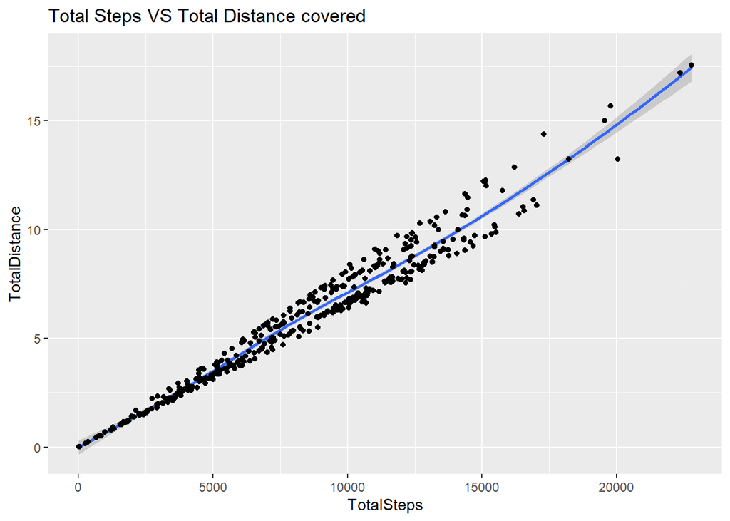

```r
ggplot(data = ActiveSleep)+
  geom_smooth(aes(x=TotalSteps, y=TotalDistance))+
  geom_point(aes(x=TotalSteps, y=TotalDistance))+
  labs(title = "Total Steps VS Total Distance covered")
```

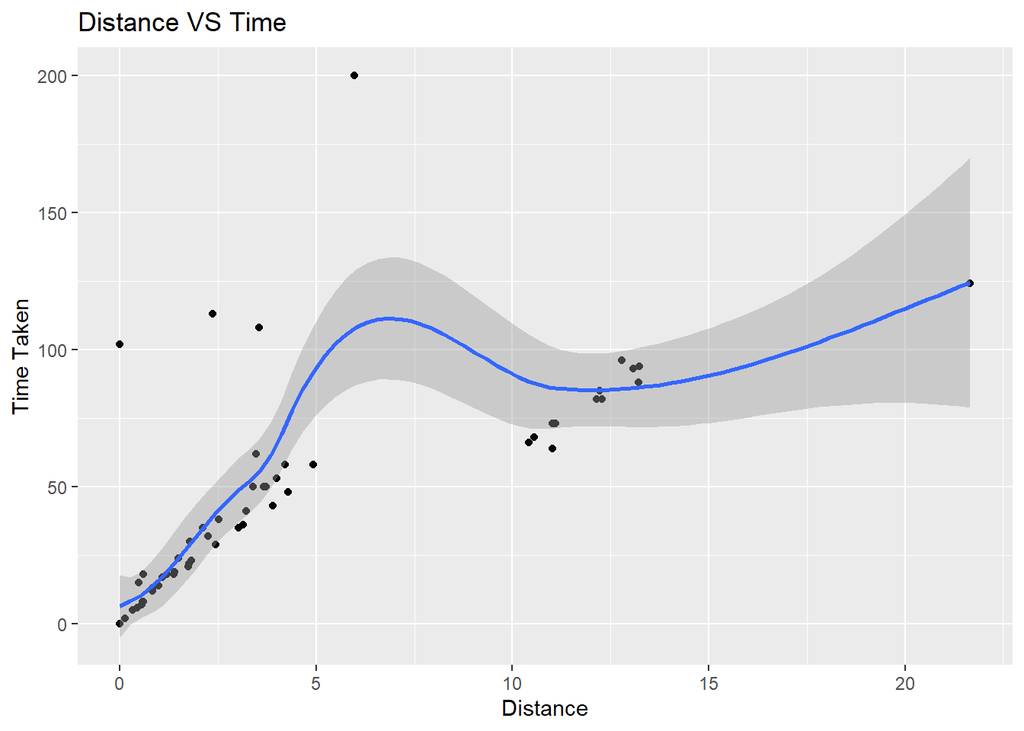

```r
ggplot(data = IntensityWeight)+
  geom_point(aes(x=VeryActiveDistance, y=VeryActiveMinutes))+
  geom_smooth(aes(x=VeryActiveDistance, y=VeryActiveMinutes))+
  labs(title = "Distance VS Time", x="Distance", y="Time Taken")
```

*3-Total Distance VS Calories burnt*

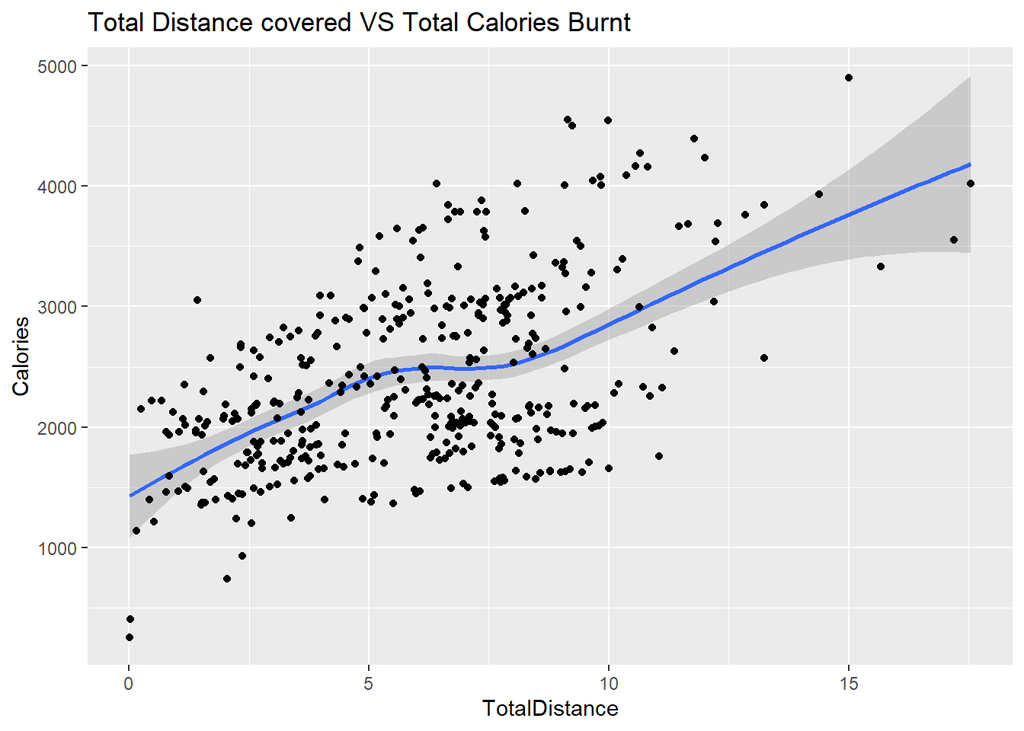

```r
ggplot(data = ActiveSleep)+
  geom_smooth(aes(x=TotalDistance, y=Calories))+
  geom_point(aes(x=TotalDistance, y=Calories))+
  labs(title = "Total Distance covered VS Total Calories Burnt")
```

*4-Time spent sleeping VS Time spent in Bed*

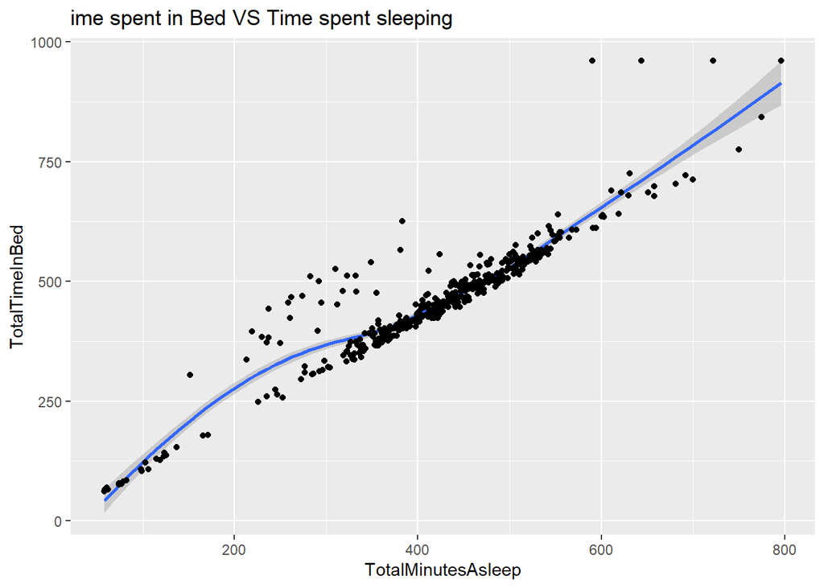

```r
ggplot(data = ActiveSleep)+
  geom_smooth(aes(x=TotalMinutesAsleep, y=TotalTimeInBed))+
  geom_point(aes(x=TotalMinutesAsleep, y=TotalTimeInBed))+
  labs(title = "ime spent in Bed VS Time spent sleeping")
```

Now, that we have visualized the given questions, let’s identify some patterns and generate key insights:

**Key Findings and Insights:**

Let’s finish the sharing stage by saving the workbook files “ActiveSleep” and “IntensityWeight” in system directory:

```r
#Saving the workbook in the system directory
write.csv(ActiveSleep,"C:/Users/laksd/OneDrive/Desktop/Analytics/Datasets/fitbit_Data_for_Bellabeat/Fitabase Data 4.12.16-5.12.16/ActiveSleep_workbook.csv", row.names = FALSE)

write.csv(IntensityWeight, "C:/Users/laksd/OneDrive/Desktop/Analytics/Datasets/fitbit_Data_for_Bellabeat/Fitabase Data 4.12.16-5.12.16/IntensityWeight_workbook", row.names = FALSE)
```

Let’ establish some recommendations based on our insights in the next and final stage of this process.

## ACT

**Final Thought** I’d recommend to use more bigger datasets with more records , because if we have a larger volume of data the tendency of the analysis to generate more accurate and pinpointed insights increases exponentially.

Also, we should also incluse more parameters for measures especially for women like “menstural cycle predications” and “heartrate” to understnad the stress levels.

From the analysis, one thing is clear that smart devices users can easliy track their fitness parameters for better health which could be used as a basis of our new marketing campaign to raise the awareness about Bellabeat Fitness smart devices.

For the purpose of this project, i will use “Bellabeat mobile app” in the presentation to highlight what type of data we can push to our customers through livetracking and sending them notifications based on thier performance.

**Recommendations**

1-Improve our user interface on the app by providing real-time personalized notifications to the customers, encourage them to engage more in the pysical activites like walking, running etc.

<- We can also provide real-time sleeplog activities highlighting and recording the sleep quality, number of timer woke up in night, total amount of awake time in the bed, anxiety & stress levels.

2-We can extend our service domain by providing in-app service for better sleep or focus & concentration or meditation. This could be a lucrative option as we will have a one-stop health app for our customers.

3-We can also provide discounts on our other Bellabeat products and services by in-app advertisement.

*Based on my analysis report, these were some specific recommendations which can help Bellabeat improve the current marketing strategy and generate revenue.*

With this, i conclude my Case study on Bellabeat Data Analytics Report!